# DATASCI 151 - Quiz #1

This quiz is open book

- You CAN use all material from the course repo
- You should NOT use other resources outside the course repo.
- You should NOT collaborate with other students
- AI assistance is NOT permitted for this assignment.
- To get full credit, the code should work as intended. But try to attempt every problem - you can still receive partial credit.

Print the following string:

"I will abide by Emory's code of conduct"

```python
print("I will abide by Emory's code of conduct")
```

```
I will abide by Emory's code of conduct
```

Import the libraries `numpy`, `matplotlib.pyplot`, and `pandas`. You probably want to give them aliases (nicknames) but it's not required.

```python
# import necessary libraries here
import numpy as np
import matplotlib.pyplot as plt
import pandas as pd
```

**(a)** Read in data, generate descriptive statistics, create a scatter plot

- Using `pandas`, read in the file "StudentPerformanceFactors.csv" from the "quiz_data" folder and assign it to a variable named `df`.
- Create a new variable by typing `cols = df.columns`. This corresponds to the column headings of the dataset.
- Determine what **type** (a.k.a class) of object the variable `cols` is, and print it to the screen.

```python
# your code here
df = pd.read_csv("quiz_data/StudentPerformanceFactors.csv")
cols = df.columns
print(type(cols))
```

```
<class 'pandas.core.indexes.base.Index'>
```

You should see a type we haven't dealt with explicitly yet. Nevertheless, we can access the individual elements of `cols` in exactly the same way as for lists or arrays.

- Using the `.describe` method, generate descriptive statistics for the variable "Previous_Scores" and print it to the screen.
- You should **not** explicitly type the string "Previous_Scores", and you **should** use the variable `cols` you created above.

```python
# your code here
df[cols[3]].describe()
```

```
count    6607.000000
mean       75.070531
std        14.399784
min        50.000000
25%        63.000000
50%        75.000000
75%        88.000000
max       100.000000
Name: Previous_Scores, dtype: float64
```

- Generate a scatter plot of "Attendance" vs. "Exam_Score" for the dataset. ("Attendance" should be the x-axis variable.)
- You should **not** explicitly type the strings "Attendance" or "Exam_Score", and you **should** use the variable `cols` you created above.
- Add labels to both the x and y axes, and add a title to your figure.
- Use `plt.show()` to ensure no extraneous output is printed to the screen.

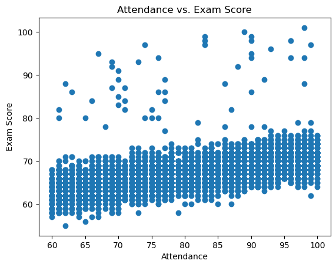

```python
# your code here

plt.scatter(x=df[cols[1]], y=df[cols[6]])
plt.xlabel("Attendance")
plt.ylabel("Exam Score")
plt.title("Attendance vs. Exam Score")
plt.show()
```

**(b)** String concatenation and list indexing

The goal of this exercise is to define a string variable `message` that contains the string  
"Peter's favorite song: 'More Than This' by Roxy Music"

- Change the definition of the variable `message` in the code cell below to coincide with the string mentioned above.
- You should **only** change the line where `message` is defined. You shouldn't create any additional variables.
- You should **not** type any strings explicitly (no using any double or single quotes).
- Remember that `...` (an ellipsis) is just a placeholder for missing or uncompleted code. You should delete the ellipsis from the line of code.

```python
lst = [" Music", "Peter's favorite song", ": ", "by ",
    "'More Than This'", " ", "Roxy"]

# change the definition of "message" below. ONLY change this line.
message = lst[1] + lst[2] + lst[4] + lst[5] + lst[3] + lst[6] + lst[0]

print(message)
```

```
Peter's favorite song: 'More Than This' by Roxy Music
```

**(c)** Generate a vector of values

- Below, two lists are defined containing values of $x_k$ and $y_k$

[output not shown]

- Create a vector (**vector always means numpy array**) `z_array` with elements $z_k$ defined by the formula

$$ z_k = 2\cdot x_k + y_k^3 - 1$$

- You **should not** define it manually. You must use the variables `coord_x` and `coord_y` in your solution. So the following is **not** an acceptable answer:

```
        z_array = np.array([-4, -1, 2, 11, 32])
```

Print `z_array` to the screen.

```python
coord_x = [-1, 0, 1, 2, 3]
coord_y = [-1, 0, 1, 2, 3]

# your code here
z_array = (2 * np.array(coord_x)) + (np.array(coord_y) ** 3) - 1

print(z_array)
```

```
[-4 -1  2 11 32]
```

**(d)** Piecewise-defined function

Consider the piecewise-defined expression

$$ y = \begin{cases} 0 & \text{if } x \le 0 \\[6pt] \dfrac{1}{2}x & \text{if } 0 < x \le \tfrac{1}{2} \\[10pt] \dfrac{1}{2}(1 - x) & \text{if } \tfrac{1}{2} < x \le 1 \\[6pt] 0 & \text{if } 1 < x \end{cases} $$

In the code cell below, a random number `x` is generated uniformly between $-1/2$ and $3/2$. Using `if`, `elif`, and/or `else` statements, write code that defines a variable `y` that is determined by the expression above. Then print it to the screen.

```python
import random
x = random.uniform(-0.5, 1.5)


# your code below

y = 0
if x > 0.5 and x <= 1:
    y = 0.5 * (1 - x)
elif x > 0 and x <= 0.5:
    y = 0.5 * (x)

print(y)
```

```
0
```

**(e)** Calculate the mean of different variables/columns of a dataset.

- Using `pandas`, read in the file "features_clean.csv" from the "quiz_data" folder and assign it to a variable named `df`.
- Using a `for` loop, print the **mean** of each variable/column of the dataset to the screen. You can simply print the numeric value of each, there is no need to print the variable name to the screen or round to 2 digits after the decimal point (although it is good practice to try if you have time).
- To compute the mean of a variable/column of a Pandas DataFrame (dataset), you can treat the column as if it were a NumPy array.

**Hint:** In question (a), you were able to use indexing on `cols` just as if it were a list. You can also loop over `cols` just like a list

```python
# your code here
df = pd.read_csv("quiz_data/features_clean.csv")
for col in df.columns:
    print(np.mean(df[col]))
```

```
23.514572864321607
5.454773869346734
193.42713567839195
104.46938775510205
2970.424623115578
15.568090452261307
```

**(f)** `For` loops with conditional statements

In the code block below, 3 lists are created containing information for 10 patients:

- `patient_id_lst` contains unique identification numbers for the 10 patients.
- `systolic_bp_lst` contains systolic blood pressure values for the 10 patients.
- `age_lst` contains the age (in years) for the 10 patients.

The ordering of the lists are consistent, so that patient "A1023" is 72 years old with a systolic blood pressure of 138. Patient "A1044" is 60 years old with a systolic blood pressure of 142, etc.

Using a **for** loop, append the patient IDs of all "at-risk" patients (those who meet the criteria listed above) to the initially empty list `at_risk`.

Then **print** `at_risk` to the screen.

```python
patient_id_lst   = ["A1023", "A1044", "B2331", "B2440", "C3001", "C3120",
    "D4105", "D4119", "E5202", "E5307"]
systolic_bp_lst  = [138, 142, 152,  171, 155,  119, 144, 140, 132, 139]
age_lst          = [72,   60,   68,  65,  82,   34,  55,  70,  67, 75]

at_risk = []

bp_cut_off = 140
age_cut_off = 65

# your code below

for (i, id) in enumerate(patient_id_lst):
    if age_lst[i] >= age_cut_off or systolic_bp_lst[i] >= bp_cut_off:
        at_risk.append(id)

print(at_risk)
```

```
['A1023', 'A1044', 'B2331', 'B2440', 'C3001', 'D4105', 'D4119', 'E5202', 'E5307']
```